# Lab 2: Clustering

Reto Wüest

July 03, 2018

This exercise is based on James et al. 2013, chapter 10.5.

## *K*-Means Clustering

We start with *K*-means clustering. We try to dermine whether there are groups of similar observations in our data. We need to decide ex-ante how many clusters we are looking for.

We first create some fake data and visualize it.

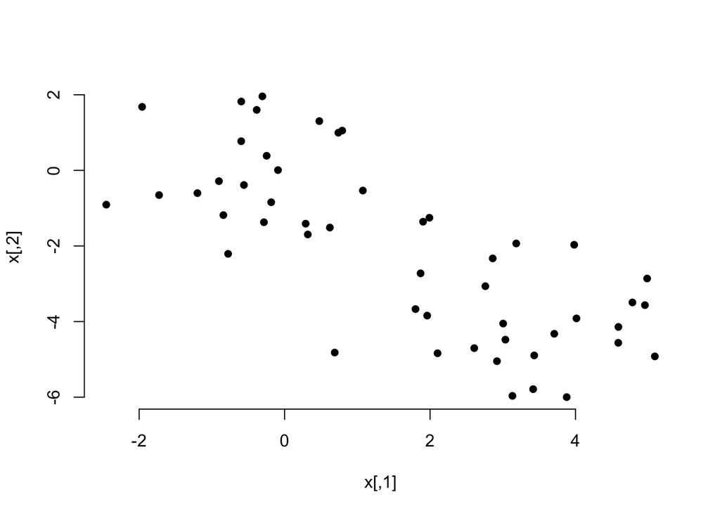

```r
set.seed(2)

# Fake data: 2 columns of 50 obs from standard normal
x <- matrix(rnorm(50 * 2), ncol = 2)

# Adding a systematic offset to first half of col 1 and 2
x[1:25, 1] <- x[1:25, 1] + 3  # offset by 3
x[1:25, 2] <- x[1:25, 2] - 4  # offset by -4

# Visualize the data
plot(x, pch = 16, bty = "n")
```

In the plot we can see the two groups. We perfom *K*-means clustering with the `kmeans()` function. The first argument is the data, the second the number of clusters, and the third the number of times we try clustering using different starting points (clusters might depend on the starting values as the algorithm can only garantuee a local optimum).

We also check the cluster assignment for each observation and color the dots in our plot according to which cluster it has been assigned to.

```r
# Run K-means clustering
km_out <- kmeans(x, 2, nstart = 20)

# For each observation what cluster has it been assigned to?
km_out$cluster
```

```
##  [1] 2 2 2 2 2 2 2 2 2 2 2 2 2 2 2 2 2 2 2 2 2 2 2 2 2 1 1 1 1 1 1 1 1 1 1
## [36] 1 1 1 1 1 1 1 1 1 1 1 1 1 1 1
```

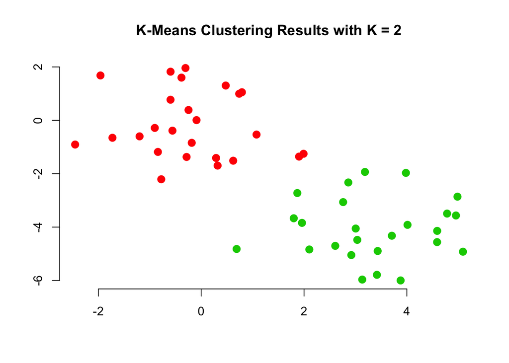

```r
# How are the observations clustered?
plot(x, col = (km_out$cluster + 1),  # plus because the first color is black
main = "K-Means Clustering Results with K = 2",
xlab = "", ylab = "", pch = 20, cex = 2, bty = "n")
```

This looks good, but might there be three groups? We do *K*-means clustering with `K = 3` and inspect the results.

```r
# K = 3
set.seed(4)
km_out_2 <- kmeans(x, 3, nstart = 20)
km_out_2
```

```
## K-means clustering with 3 clusters of sizes 10, 23, 17
##
## Cluster means:
##         [,1]        [,2]
## 1  2.3001545 -2.69622023
## 2 -0.3820397 -0.08740753
## 3  3.7789567 -4.56200798
##
## Clustering vector:
##  [1] 3 1 3 1 3 3 3 1 3 1 3 1 3 1 3 1 3 3 3 3 3 1 3 3 3 2 2 2 2 2 2 2 2 2 2
## [36] 2 2 2 2 2 2 2 2 1 2 1 2 2 2 2
##
## Within cluster sum of squares by cluster:
## [1] 19.56137 52.67700 25.74089
##  (between_SS / total_SS =  79.3 %)
##
## Available components:
##
## [1] "cluster"      "centers"      "totss"        "withinss"
## [5] "tot.withinss" "betweenss"    "size"         "iter"
## [9] "ifault"
```

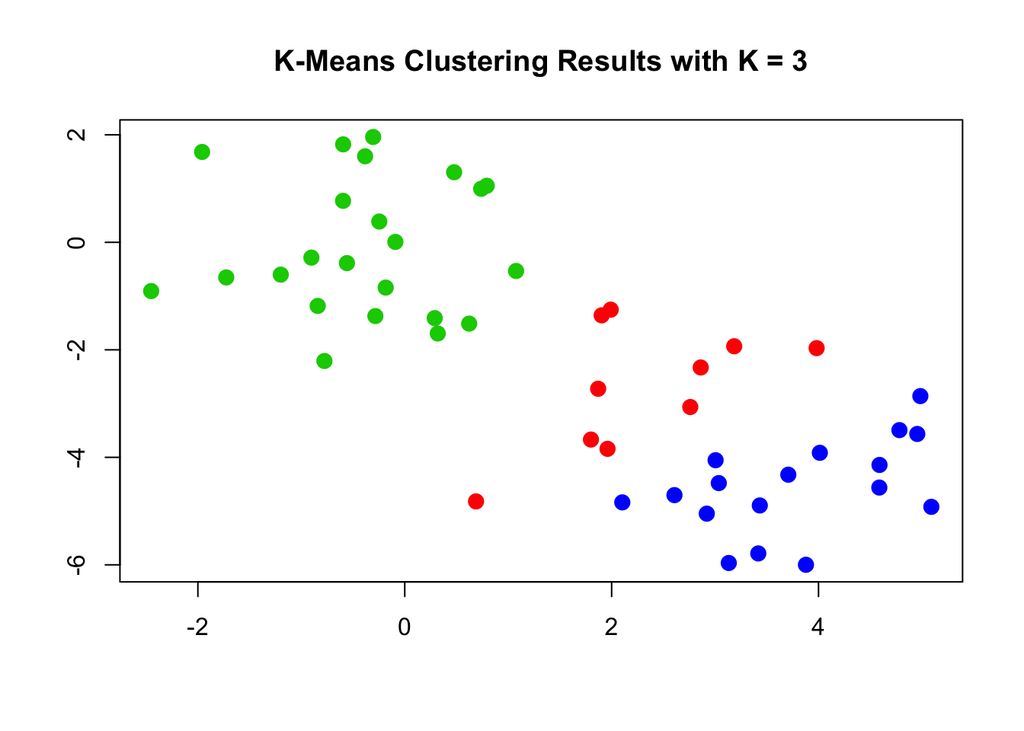

```r
# Visualize again cluster assignment
plot(x, col = (km_out_2$cluster + 1),
main = "K-Means Clustering Results with K = 3",
xlab = "", ylab = "", pch = 20, cex = 2)
```

We can check what happens when we do not use enough randomly assigned starting points. We could end up with a solution that is far from optimal.

```r
# Set nstart large enough
set.seed(3)

km_out_3 <- kmeans(x, 3, nstart = 1)
km_out_3$tot.withinss  # this is the total within-cluster sum of squares, which we seek to minimize by performing K-means clustering
```

```
## [1] 104.3319
```

```r
km_out_4 <- kmeans(x, 3, nstart = 20)
km_out_4$tot.withinss
```

```
## [1] 97.97927
```

## Hierarchical Clustering

We now move to hierachical clustering where we do not pre-set the number of clusters. We use the function `hclust()`. We need to specify whether we want to cluster according to distance or correlation and we need to specify a linkage.

```r
# Run clustering
hc_complete <- hclust(dist(x), method = "complete")
hc_average <- hclust(dist(x), method = "average")
hc_single <- hclust(dist(x), method = "single")
```

The choice of the method is consequential, as we end up with different clusterings. The most common choice is “complete” or “average”" which tends to produce more balanced dendrograms.

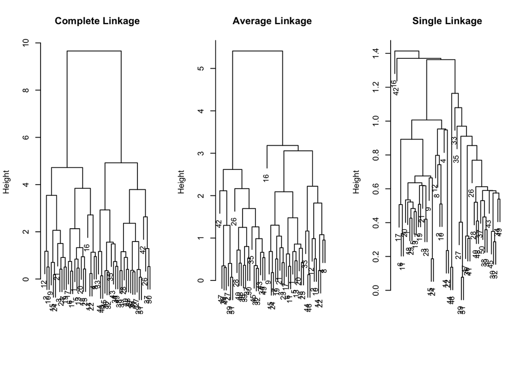

```r
# Complete (maximum distance)
par(mfrow = c(1, 3))
plot(hc_complete, main = "Complete Linkage",
xlab = "", sub = "", cex = 0.9)

# Average
plot(hc_average, main = "Average Linkage",
xlab = "", sub = "", cex = 0.9)

# Mimimum distance
plot(hc_single, main = "Single Linkage",
xlab = "", sub = "", cex = 0.9)
```

Based on these dendrograms we have to decide how many clusters make sense in the data. This may be quite difficult without substantial knowledge. We can check cluster assignment given an amount of clusters that we specify with the `cutree()` function.

```r
# Cluster assignment for 2 clusters
cutree(hc_complete, 2)
```

```
##  [1] 1 1 1 1 1 1 1 1 1 1 1 1 1 1 1 1 1 1 1 1 1 1 1 1 1 2 2 2 2 2 2 2 2 2 2
## [36] 2 2 2 2 2 2 2 2 2 2 2 2 2 2 2
```

```r
cutree(hc_average, 2)
```

```
##  [1] 1 1 1 1 1 1 1 1 1 1 1 1 1 1 1 1 1 1 1 1 1 1 1 1 1 2 2 2 2 2 2 2 1 2 2
## [36] 2 2 2 2 2 2 2 2 1 2 1 2 2 2 2
```

```r
cutree(hc_single, 2)
```

```
##  [1] 1 1 1 1 1 1 1 1 1 1 1 1 1 1 1 2 1 1 1 1 1 1 1 1 1 1 1 1 1 1 1 1 1 1 1
## [36] 1 1 1 1 1 1 1 1 1 1 1 1 1 1 1
```

```r
# Cluster assignment for 4 clusters
cutree(hc_single, 4)
```

```
##  [1] 1 1 1 1 1 1 1 1 1 1 1 1 1 1 1 2 1 1 1 1 1 1 1 1 1 3 3 3 3 3 3 3 3 3 3
## [36] 3 3 3 3 3 3 4 3 3 3 3 3 3 3 3
```

Just like with *K*-nearest neighbors, distance based clustering suffers when the variables are measured on different scales. Therefore, we scale our variables and cluster again.

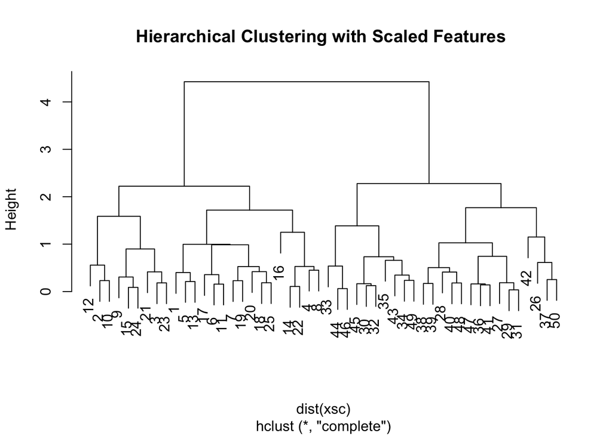

```r
# Scaling to get variable on the same scale
xsc <- scale(x)
par(mfrow = c(1,1) )
plot(hclust(dist(xsc), method = "complete"),
main = "Hierarchical Clustering with Scaled Features ")
```

Instead of using distance as our similarity measure, we could use correlation. This makes sense when we are interested to uncover common trends.

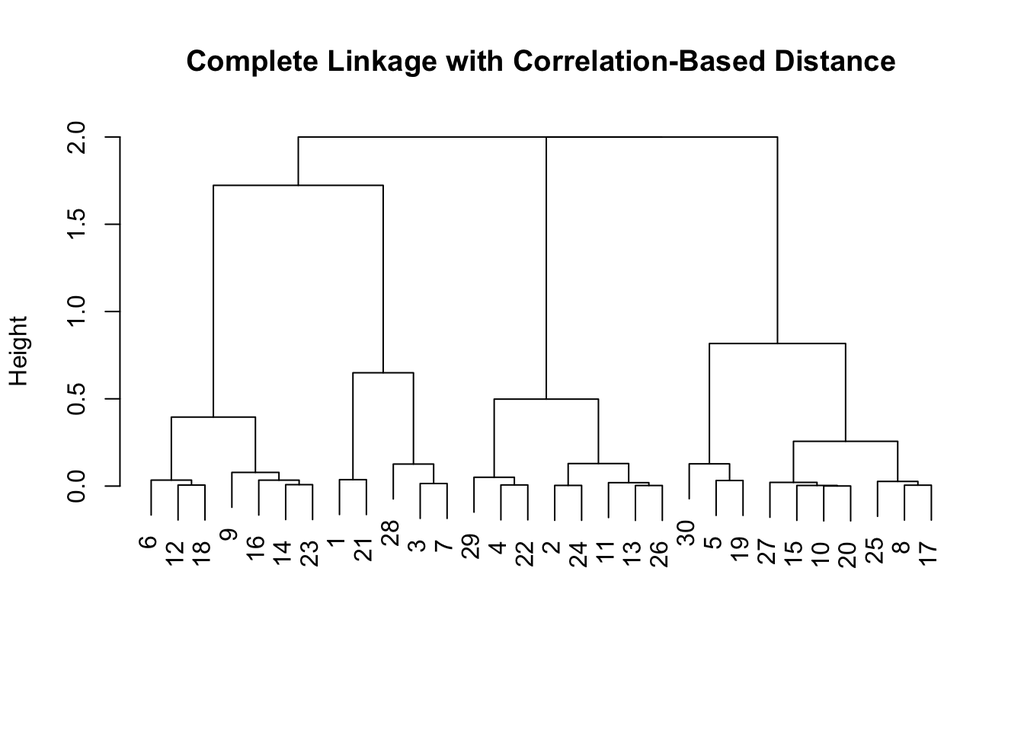

```r
# Use different similarity measure
x <- matrix(rnorm(30 * 3), ncol = 3)  # new fake data
dd <- as.dist(1 - cor(t(x) ))
plot(hclust(dd, method = "complete"),
main = "Complete Linkage with Correlation-Based Distance",
xlab = "", sub = "")
```